# Predictive Analytics & Machine Learning for Acute Stroke Mortality

Beth

## 1. Project Overview & Environment Setup

This project develops, evaluates, and compares interpretable machine learning models to predict in-hospital mortality following acute stroke presentation. Using a synthetic clinical dataset incorporating patient demographics, physiological baseline metrics, presenting symptoms, neuroimaging features, and acute treatments, I compare **LASSO Regularized Logistic Regression** against **XGBoost Gradient Boosted Trees**.

### Key Analytical Goals:

1. Conduct extensive Exploratory Data Analysis (EDA) and non-parametric hypothesis testing.
2. Address class imbalance via empirical positive-class reweighting.
3. Optimize hyperparameters via Cross-Validation (Deviance for LASSO; PR-AUC for XGBoost).
4. Evaluate models using threshold-calibrated clinical metrics (Sensitivity, Specificity, PPV, NPV, ROC-AUC, PR-AUC, Log Loss).
5. Explain feature contributions using L2-norm grouped coefficients and SHAP (SHapley Additive exPlanations).

```r
library(tidyverse)
library(gtsummary)
library(gt)
library(ggplot2)
library(patchwork)
library(scales)
library(caret)
library(glmnet)
library(ggcorrplot)
library(pROC)
library(PRROC)
library(xgboost)
library(SHAPforxgboost)

# Load dataset
data <- read.csv("assignment2026.csv")
```

## 2. Exploratory Data Analysis (EDA) & Descriptive Statistics

### 2.1 Baseline Dataset Inspection & Data Types

```r
# Overview of variable distributions and summary statistics
summary(data)
```

```
##      delay          consc              gender               age
##  Min.   : 1.00   Length:13063       Length:13063       Min.   :16.00
##  1st Qu.:10.00   Class :character   Class :character   1st Qu.:64.00
##  Median :20.00   Mode  :character   Mode  :character   Median :72.00
##  Mean   :20.66                                         Mean   :70.49
##  3rd Qu.:30.00                                         3rd Qu.:79.00
##  Max.   :48.00                                         Max.   :98.00
##    wakesym             atrial               CT               Infarc
##  Length:13063       Length:13063       Length:13063       Length:13063
##  Class :character   Class :character   Class :character   Class :character
##  Mode  :character   Mode  :character   Mode  :character   Mode  :character
##
##
##
##     hep24               asp3                sbp          symptom1
##  Length:13063       Length:13063       Min.   : 70.0   Length:13063
##  Class :character   Class :character   1st Qu.:140.0   Class :character
##  Mode  :character   Mode  :character   Median :160.0   Mode  :character
##                                        Mean   :160.5
##                                        3rd Qu.:180.0
##                                        Max.   :295.0
##    symptom2           symptom3           symptom4           symptom5
##  Length:13063       Length:13063       Length:13063       Length:13063
##  Class :character   Class :character   Class :character   Class :character
##  Mode  :character   Mode  :character   Mode  :character   Mode  :character
##
##
##
##    symptom6           symptom7           symptom8           subtype
##  Length:13063       Length:13063       Length:13063       Length:13063
##  Class :character   Class :character   Class :character   Class :character
##  Mode  :character   Mode  :character   Mode  :character   Mode  :character
##
##
##
##     treat1             treat2              death
##  Length:13063       Length:13063       Min.   :0.00000
##  Class :character   Class :character   1st Qu.:0.00000
##  Mode  :character   Mode  :character   Median :0.00000
##                                        Mean   :0.04685
##                                        3rd Qu.:0.00000
##                                        Max.   :1.00000
```

```r
# Check for missing values across all columns
missing_count <- sum(!complete.cases(data))
cat("Total missing data records:", missing_count, "\n")
```

```
## Total missing data records: 0
```

```r
# Format primary outcome: Binary Mortality (0 = Survived, 1 = Died)
data$death <- factor(data$death,
                    levels = c(0, 1),
                    labels = c("Survived", "Died"))

# Convert clinical categorical variables and indicators to factors
factor_vars <- c("consc", "gender", "wakesym", "atrial", "CT", "Infarc", "hep24", "asp3",
                 paste0("symptom", 1:8), "subtype", "treat1", "treat2")


factor_vars <- intersect(factor_vars, names(data))
data[factor_vars] <- lapply(data[factor_vars], factor)
```

```r
# Generate Table 1 by outcome status
table1 <- data %>%
  tbl_summary(
    by = death,
    statistic = list(
      all_continuous() ~ "{mean} ({sd}) | {median} ({IQR})",
      all_categorical() ~ "{n} ({p}%)"
    ),
    digits = all_continuous() ~ 1
  ) %>%
  add_overall() %>%
  bold_labels()

gt_table1 <- as_gt(table1)
gt_table1
```

| **Characteristic** | **Overall** N = 13,063<sup>1</sup> | **Survived** N = 12,451<sup>1</sup> | **Died** N = 612<sup>1</sup> |
| --- | --- | --- | --- |
| delay | 20.7 (12.4) \| 20.0 (20.0) | 20.8 (12.4) \| 20.0 (20.0) | 18.0 (12.0) \| 15.0 (17.0) |
| consc |  |  |  |
| D | 1,496 (11%) | 1,260 (10%) | 236 (39%) |
| F | 11,567 (89%) | 11,191 (90%) | 376 (61%) |
| gender |  |  |  |
| F | 5,730 (44%) | 5,446 (44%) | 284 (46%) |
| M | 7,333 (56%) | 7,005 (56%) | 328 (54%) |
| age | 70.5 (11.7) \| 72.0 (15.0) | 70.2 (11.7) \| 72.0 (16.0) | 75.6 (9.9) \| 77.0 (13.0) |
| wakesym |  |  |  |
| N | 9,072 (69%) | 8,643 (69%) | 429 (70%) |
| Y | 3,991 (31%) | 3,808 (31%) | 183 (30%) |
| atrial |  |  |  |
| N | 11,244 (86%) | 10,799 (87%) | 445 (73%) |
| Y | 1,819 (14%) | 1,652 (13%) | 167 (27%) |
| CT |  |  |  |
| N | 4,371 (33%) | 4,147 (33%) | 224 (37%) |
| Y | 8,692 (67%) | 8,304 (67%) | 388 (63%) |
| Infarc |  |  |  |
| N | 9,111 (70%) | 8,725 (70%) | 386 (63%) |
| Y | 3,952 (30%) | 3,726 (30%) | 226 (37%) |
| hep24 |  |  |  |
| N | 12,752 (98%) | 12,159 (98%) | 593 (97%) |
| Y | 311 (2.4%) | 292 (2.3%) | 19 (3.1%) |
| asp3 |  |  |  |
| N | 10,294 (79%) | 9,800 (79%) | 494 (81%) |
| Y | 2,769 (21%) | 2,651 (21%) | 118 (19%) |
| sbp | 160.5 (27.5) \| 160.0 (40.0) | 160.6 (27.3) \| 160.0 (40.0) | 158.1 (30.2) \| 156.0 (40.0) |
| symptom1 |  |  |  |
| N | 3,933 (30%) | 3,846 (31%) | 87 (14%) |
| Y | 9,130 (70%) | 8,605 (69%) | 525 (86%) |
| symptom2 |  |  |  |
| N | 2,069 (16%) | 2,026 (16%) | 43 (7.0%) |
| Y | 10,994 (84%) | 10,425 (84%) | 569 (93%) |
| symptom3 |  |  |  |
| N | 3,517 (27%) | 3,446 (28%) | 71 (12%) |
| Y | 9,546 (73%) | 9,005 (72%) | 541 (88%) |
| symptom4 |  |  |  |
| N | 8,414 (64%) | 8,098 (65%) | 316 (52%) |
| Y | 4,649 (36%) | 4,353 (35%) | 296 (48%) |
| symptom5 |  |  |  |
| N | 10,888 (83%) | 10,514 (84%) | 374 (61%) |
| Y | 2,175 (17%) | 1,937 (16%) | 238 (39%) |
| symptom6 |  |  |  |
| N | 11,059 (85%) | 10,648 (86%) | 411 (67%) |
| Y | 2,004 (15%) | 1,803 (14%) | 201 (33%) |
| symptom7 |  |  |  |
| N | 11,492 (88%) | 10,954 (88%) | 538 (88%) |
| Y | 1,571 (12%) | 1,497 (12%) | 74 (12%) |
| symptom8 |  |  |  |
| N | 12,272 (94%) | 11,701 (94%) | 571 (93%) |
| Y | 791 (6.1%) | 750 (6.0%) | 41 (6.7%) |
| subtype |  |  |  |
| LACS | 4,393 (34%) | 4,308 (35%) | 85 (14%) |
| OTH | 47 (0.4%) | 45 (0.4%) | 2 (0.3%) |
| PACS | 5,540 (42%) | 5,278 (42%) | 262 (43%) |
| POCS | 1,655 (13%) | 1,581 (13%) | 74 (12%) |
| TACS | 1,428 (11%) | 1,239 (10.0%) | 189 (31%) |
| treat1 |  |  |  |
| L | 3,274 (25%) | 3,128 (25%) | 146 (24%) |
| M | 3,267 (25%) | 3,114 (25%) | 153 (25%) |
| N | 6,522 (50%) | 6,209 (50%) | 313 (51%) |
| treat2 |  |  |  |
| N | 6,519 (50%) | 6,200 (50%) | 319 (52%) |
| Y | 6,544 (50%) | 6,251 (50%) | 293 (48%) |

<sup>1</sup> Mean (SD) | Median (IQR); n (%)

### 2.2 Analysis of Continuous Predictors

I analysed differences in key continuous clinical measurements—Treatment Delay (hours), Patient Age (years), and Systolic Blood Pressure, between survivors and non-survivors using non-parametric **Wilcoxon Rank-Sum Tests (Mann-Whitney U Tests)** due to skewed distributional shapes.

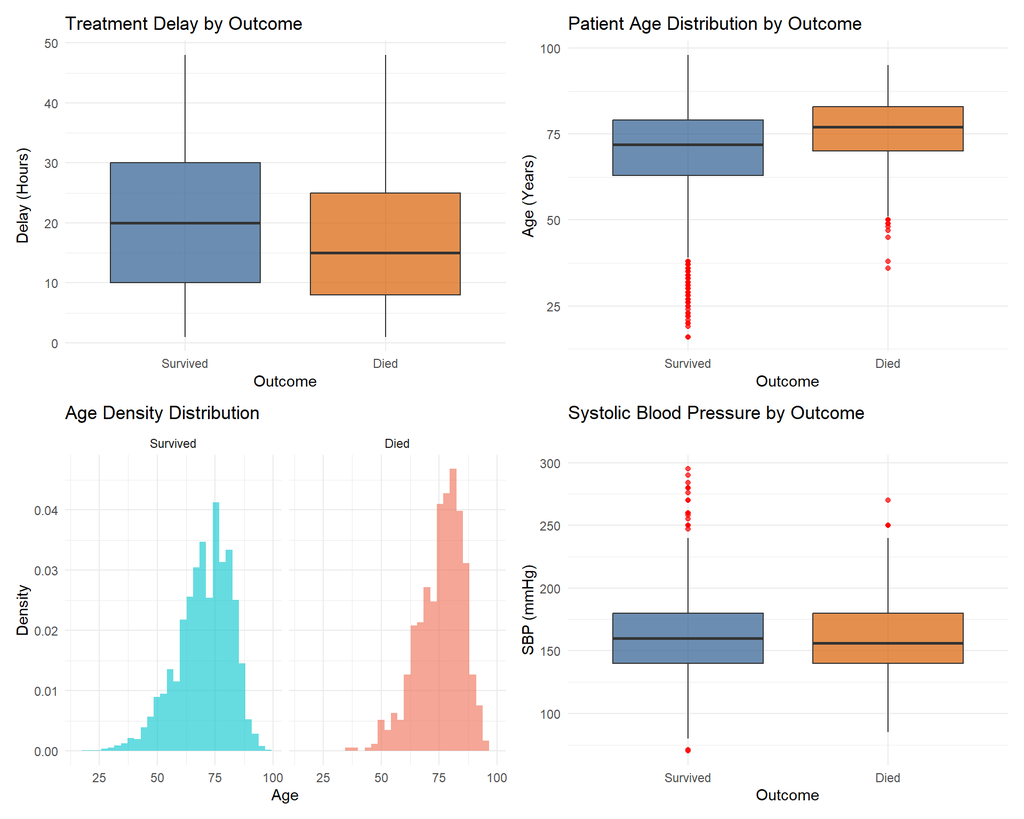

```r
# Boxplot: Hours delay before treatment by outcome
delay_box <- ggplot(data, aes(x = death, y = delay, fill = death)) +
  geom_boxplot(alpha = 0.7, outlier.colour = "red") +
  scale_fill_manual(values = c("Survived" = "#2b5c8f", "Died" = "#d95f02")) +
  labs(title = "Treatment Delay by Outcome", x = "Outcome", y = "Delay (Hours)") +
  theme_minimal() +
  theme(legend.position = "none")

# Boxplot: Patient Age by outcome
age_box <- ggplot(data, aes(x = death, y = age, fill = death)) +
  geom_boxplot(alpha = 0.7, outlier.colour = "red") +
  scale_fill_manual(values = c("Survived" = "#2b5c8f", "Died" = "#d95f02")) +
  labs(title = "Patient Age Distribution by Outcome", x = "Outcome", y = "Age (Years)") +
  theme_minimal() +
  theme(legend.position = "none")

# Density Histogram: Age comparison
age_hist <- ggplot(data) +
  geom_histogram(aes(x = age, y = after_stat(density), fill = death), bins = 30, alpha = 0.6, position = "identity") +
  facet_wrap(~ death) +
  scale_fill_manual(values = c("Survived" = "turquoise3", "Died" = "coral2")) +
  labs(title = "Age Density Distribution", x = "Age", y = "Density") +
  theme_minimal() +
  theme(legend.position = "none")

# Boxplot: Systolic Blood Pressure (SBP) by outcome
sbp_box <- ggplot(data, aes(x = death, y = sbp, fill = death)) +
  geom_boxplot(alpha = 0.7, outlier.colour = "red") +
  scale_fill_manual(values = c("Survived" = "#2b5c8f", "Died" = "#d95f02")) +
  labs(title = "Systolic Blood Pressure by Outcome", x = "Outcome", y = "SBP (mmHg)") +
  theme_minimal() +
  theme(legend.position = "none")

# Arrange plots using patchwork
(delay_box | age_box) / (age_hist | sbp_box)
```

```r
# Wilcoxon Rank-Sum Statistical Tests
cat("--- Wilcoxon Rank-Sum Tests ---\n")
```

```
## --- Wilcoxon Rank-Sum Tests ---
```

```r
print(wilcox.test(delay ~ death, data = data))
```

```
##
##  Wilcoxon rank sum test with continuity correction
##
## data:  delay by death
## W = 4328513, p-value = 1.22e-08
## alternative hypothesis: true location shift is not equal to 0
```

```r
print(wilcox.test(age ~ death, data = data))
```

```
##
##  Wilcoxon rank sum test with continuity correction
##
## data:  age by death
## W = 2759716, p-value < 2.2e-16
## alternative hypothesis: true location shift is not equal to 0
```

```r
print(wilcox.test(sbp ~ death, data = data))
```

```
##
##  Wilcoxon rank sum test with continuity correction
##
## data:  sbp by death
## W = 4026421, p-value = 0.01704
## alternative hypothesis: true location shift is not equal to 0
```

### 2.3 Categorical Predictor Analysis & Fisher’s Exact Tests

To evaluate bivariate associations between categorical clinical factors and mortality, I performed Monte-Carlo simulated **Fisher’s Exact Tests**.

```r
# Compute Fisher's Exact Test p-values for all categorical predictors
cat_vars <- c("consc", "gender", "wakesym", "atrial", "CT", "Infarc", "hep24", "asp3",
              paste0("symptom", 1:8), "subtype", "treat1", "treat2")
cat_vars <- intersect(cat_vars, names(data))

fish_results <- data.frame(
  variable = cat_vars,
  p_value = sapply(cat_vars, function(v) {
    fisher.test(table(data$death, data[[v]]), simulate.p.value = TRUE)$p.value
  }),
  stringsAsFactors = FALSE
)

# Assign statistical significance stars
fish_results$stars <- cut(
  fish_results$p_value,
  breaks = c(-Inf, 0.001, 0.01, 0.05, Inf),
  labels = c("***", "**", "*", "ns")
)

fish_results <- fish_results[order(fish_results$p_value), ]

# Render statistical table
fish_table <- fish_results %>%
  gt() %>%
  tab_header(
    title = "Bivariate Association with Mortality",
    subtitle = "Fisher's Exact Test P-values and Significance Levels"
  ) %>%
  fmt_scientific(columns = p_value, decimals = 3) %>%
  cols_label(
    variable = "Clinical Categorical Predictor",
    p_value = "P-value",
    stars = "Significance"
  ) %>%
  tab_style(
    style = cell_text(weight = "bold"),
    locations = cells_column_labels(everything())
  )

fish_table
```

Bivariate Association with Mortality

Fisher's Exact Test P-values and Significance Levels

| Clinical Categorical Predictor | P-value | Significance |
| --- | --- | --- |
| consc | 9.677 × 10<sup>−72</sup> | *** |
| symptom5 | 1.742 × 10<sup>−41</sup> | *** |
| symptom6 | 1.614 × 10<sup>−28</sup> | *** |
| symptom3 | 4.592 × 10<sup>−21</sup> | *** |
| symptom1 | 1.110 × 10<sup>−20</sup> | *** |
| atrial | 5.289 × 10<sup>−19</sup> | *** |
| symptom2 | 3.110 × 10<sup>−11</sup> | *** |
| symptom4 | 3.832 × 10<sup>−11</sup> | *** |
| Infarc | 3.049 × 10<sup>−4</sup> | *** |
| subtype | 4.998 × 10<sup>−4</sup> | *** |
| CT | 9.546 × 10<sup>−2</sup> | ns |
| gender | 1.961 × 10<sup>−1</sup> | ns |
| hep24 | 2.210 × 10<sup>−1</sup> | ns |
| asp3 | 2.443 × 10<sup>−1</sup> | ns |
| treat2 | 2.639 × 10<sup>−1</sup> | ns |
| symptom8 | 4.871 × 10<sup>−1</sup> | ns |
| wakesym | 7.531 × 10<sup>−1</sup> | ns |
| treat1 | 7.621 × 10<sup>−1</sup> | ns |
| symptom7 | 9.493 × 10<sup>−1</sup> | ns |

### 2.4 Acute Treatment Options & Outcome Proportions

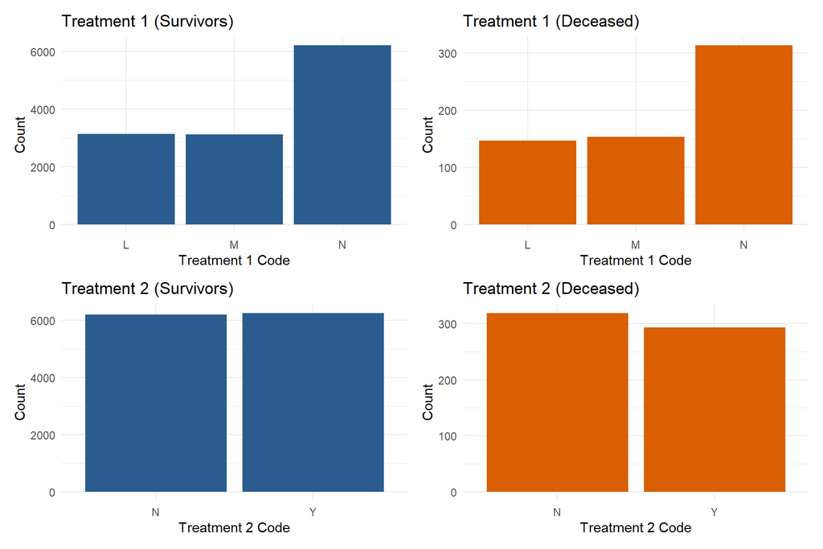

```r
# Visualising outcome distribution across treatment protocols
p1 <- ggplot(subset(data, death == "Survived"), aes(x = treat1)) +
  geom_bar(fill = "#2b5c8f") +
  labs(title = "Treatment 1 (Survivors)", x = "Treatment 1 Code", y = "Count") +
  theme_minimal()

p2 <- ggplot(subset(data, death == "Died"), aes(x = treat1)) +
  geom_bar(fill = "#d95f02") +
  labs(title = "Treatment 1 (Deceased)", x = "Treatment 1 Code", y = "Count") +
  theme_minimal()

p3 <- ggplot(subset(data, death == "Survived"), aes(x = treat2)) +
  geom_bar(fill = "#2b5c8f") +
  labs(title = "Treatment 2 (Survivors)", x = "Treatment 2 Code", y = "Count") +
  theme_minimal()

p4 <- ggplot(subset(data, death == "Died"), aes(x = treat2)) +
  geom_bar(fill = "#d95f02") +
  labs(title = "Treatment 2 (Deceased)", x = "Treatment 2 Code", y = "Count") +
  theme_minimal()

(p1 | p2) / (p3 | p4)
```

### 2.5 Pairwise Symptom & Feature Correlation Heatmap

Evaluating collinearity among binary clinical indicators informs penalization choices (e.g., L1 LASSO vs L2 Ridge).

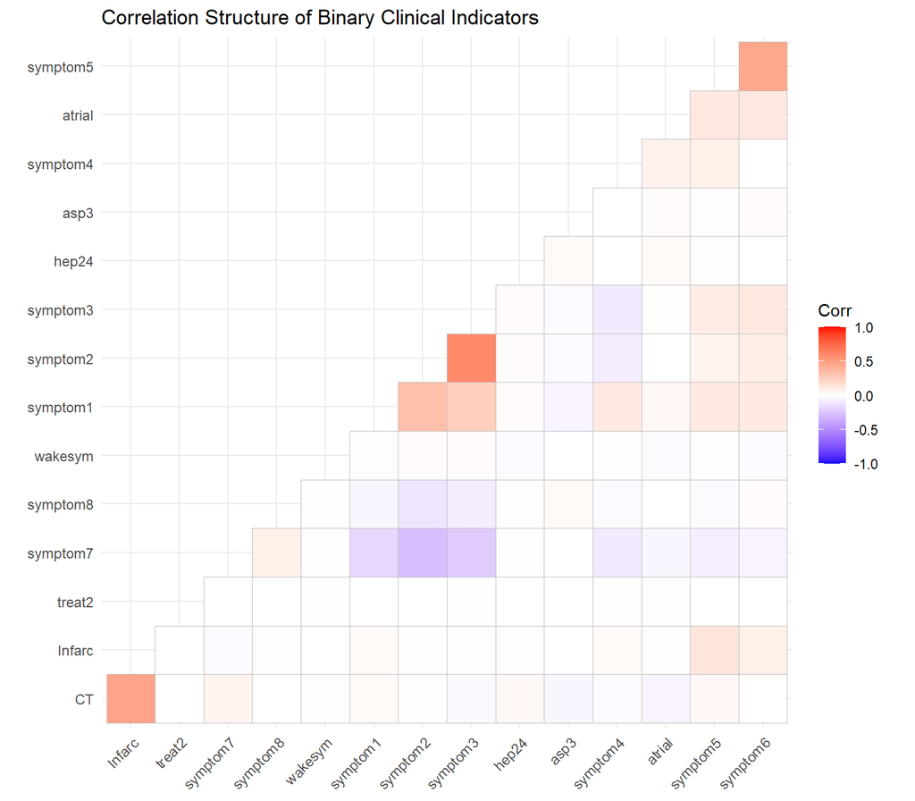

```r
yn_vars <- c("wakesym", "atrial", "CT", "Infarc", "hep24", "asp3",
             paste0("symptom", 1:8), "treat2")
yn_vars <- intersect(yn_vars, names(data))

# Encode factor values to binary 1/0 integers for Pearson correlation
yn01 <- as.data.frame(lapply(data[yn_vars], function(x) {
  x_str <- toupper(trimws(as.character(x)))
  as.integer(x_str == "Y" | x_str == "1" | x_str == "TRUE")
}))

corr_matrix <- cor(yn01, use = "pairwise.complete.obs")

cat_cor <- ggcorrplot(
  corr_matrix,
  method = "square",
  hc.order = TRUE,
  type = "lower",
  lab = FALSE,
  tl.cex = 9,
  title = "Correlation Structure of Binary Clinical Indicators"
)

cat_cor
```

### 2.6 Mortality Rate by Stroke Subtype

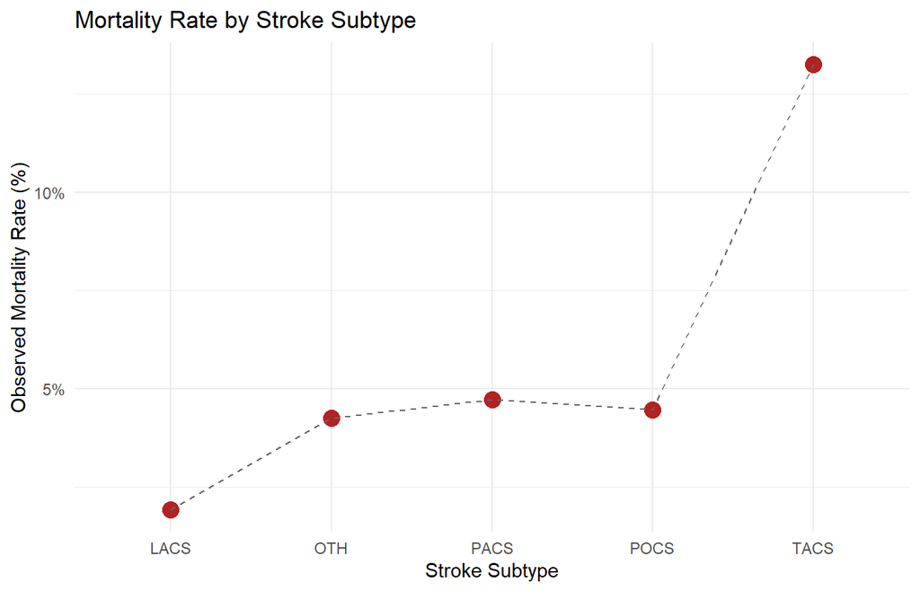

```r
death_subtype <- data %>%
  group_by(subtype) %>%
  summarise(
    total = n(),
    deaths = sum(death == "Died", na.rm = TRUE),
    death_rate = mean(death == "Died", na.rm = TRUE),
    .groups = "drop"
  ) %>%
  ggplot(aes(x = subtype, y = death_rate)) +
  geom_point(size = 4, color = "firebrick") +
  geom_line(group = 1, color = "grey40", linetype = "dashed") +
  scale_y_continuous(labels = scales::percent_format(accuracy = 1)) +
  labs(
    title = "Mortality Rate by Stroke Subtype",
    x = "Stroke Subtype",
    y = "Observed Mortality Rate (%)"
  ) +
  theme_minimal()

death_subtype
```

## 3. Data Splitting & Pre-processing

We partition the dataset into an **80% Training Set** and a **20% Independent Validation/Test Set** using stratified sampling to preserve the mortality outcome proportion.

```r
set.seed(22) # Ensure reproducible data partition

train_idx <- createDataPartition(y = data$death, p = 0.8, list = FALSE)
data_train <- data[train_idx, ]
data_val   <- data[-train_idx, ]

# Validate balance in mortality rate
cat("Training set mortality proportion:\n")
```

```
## Training set mortality proportion:
```

```r
print(prop.table(table(data_train$death)))
```

```
##
##   Survived       Died
## 0.95311453 0.04688547
```

```r
cat("Validation set mortality proportion:\n")
```

```
## Validation set mortality proportion:
```

```r
print(prop.table(table(data_val$death)))
```

```
##
##  Survived      Died
## 0.9532925 0.0467075
```

## 4. Regularized Logistic Regression (LASSO)

### 4.1 Model Matrix Formulation & Empirical Class Reweighting

LASSO ($L_1$ penalty) performs feature selection by shrinking non-informative coefficients to exactly zero. To address outcome imbalance, positive cases are weighted inversely to their sample proportion:
$$w_{\text{pos}} =
\frac{N_{\text{survived}}}{N_{\text{died}}}$$

```r
# Construct design matrices (one-hot encoding categorical factors)
x_train <- model.matrix(death ~ ., data_train)[, -1]
y_train <- data_train$death
x_test  <- model.matrix(death ~ ., data_val)[, -1]
y_test  <- data_val$death

# Numeric response vector: 1 = Died, 0 = Survived
y_train_num <- as.numeric(y_train == "Died")
y_test_num  <- as.numeric(y_test == "Died")

# Calculate empirical positive class weight for imbalanced learning
w_pos <- sum(y_train_num == 0) / sum(y_train_num == 1)
case_weights <- ifelse(y_train_num == 1, w_pos, 1)

cat("Empirical positive class weight:", round(w_pos, 2), "\n")
```

```
## Empirical positive class weight: 20.33
```

### 4.2 Cross-Validation for $\lambda$ Hyperparameter Tuning

We execute 10-fold cross-validation (`cv.glmnet`) optimizing binomial log-loss (deviance).

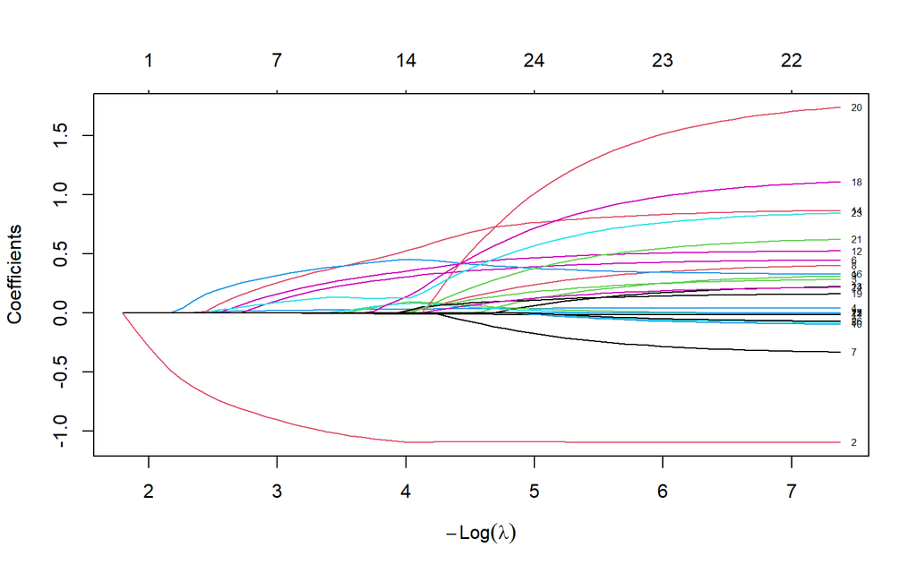

```r
# Fit LASSO coefficient path
lasso_mod <- glmnet(x_train, y_train_num, alpha = 1, family = "binomial",
                    weights = case_weights, standardize = TRUE)

plot(lasso_mod, xvar = "lambda", label = TRUE)
```

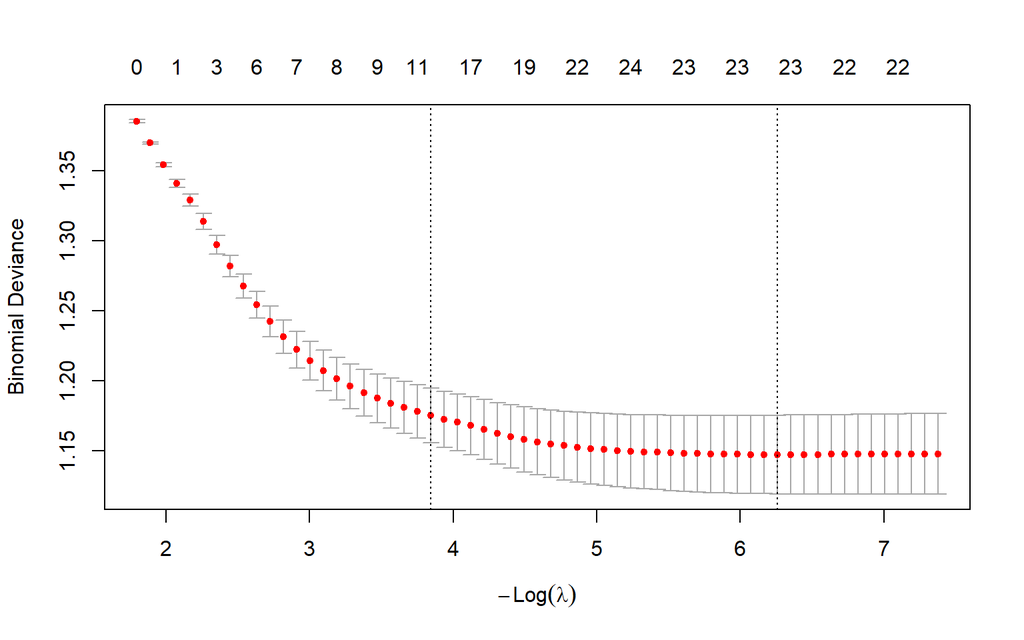

```r
# 10-fold Cross-Validation
set.seed(22)
lasso_cv <- cv.glmnet(x_train, y_train_num, alpha = 1, nfolds = 10,
                      weights = case_weights, family = "binomial",
                      type.measure = "deviance", standardize = TRUE)

plot(lasso_cv)
```

```r
best_lambda <- lasso_cv$lambda.min
lambda_1se  <- lasso_cv$lambda.1se

cat("Optimal Lambda (min deviance):", best_lambda, "\n")
```

```
## Optimal Lambda (min deviance): 0.001909631
```

```r
cat("1-SE Lambda (parsimonious):", lambda_1se, "\n")
```

```
## 1-SE Lambda (parsimonious): 0.02145134
```

```r
# Active nonzero variables count
c_min <- coef(lasso_cv, s = "lambda.min")
c_1se <- coef(lasso_cv, s = "lambda.1se")

cat("Non-zero features at lambda.min:", sum(c_min[-1] != 0), "\n")
```

```
## Non-zero features at lambda.min: 23
```

```r
cat("Non-zero features at lambda.1se:", sum(c_1se[-1] != 0), "\n")
```

```
## Non-zero features at lambda.1se: 11
```

### 4.3 Refitting Final LASSO Model & Validation Evaluation

```r
# Refit model at optimal lambda.min
lasso_final <- glmnet(x_train, y_train_num, alpha = 1, family = "binomial",
                      lambda = best_lambda, weights = case_weights, standardize = TRUE)

# Predict probabilities on Train and Test sets
ypred_train <- as.numeric(predict(lasso_final, newx = x_train, type = "response"))
ypred_test  <- as.numeric(predict(lasso_final, newx = x_test,  type = "response"))

# ROC-AUC evaluation
roc_train_lasso <- roc(y_train_num, ypred_train, quiet = TRUE)
roc_test_lasso  <- roc(y_test_num,  ypred_test,  quiet = TRUE)

# PR-AUC evaluation
pr_test_lasso  <- pr.curve(scores.class0 = ypred_test[y_test_num == 1],
                           scores.class1 = ypred_test[y_test_num == 0], curve = TRUE)
pr_train_lasso <- pr.curve(scores.class0 = ypred_train[y_train_num == 1],
                           scores.class1 = ypred_train[y_train_num == 0], curve = FALSE)

cat("LASSO Test ROC-AUC:", round(auc(roc_test_lasso), 3), "\n")
```

```
## LASSO Test ROC-AUC: 0.777
```

```r
cat("LASSO Test PR-AUC:", round(pr_test_lasso$auc.integral, 3), "\n")
```

```
## LASSO Test PR-AUC: 0.17
```

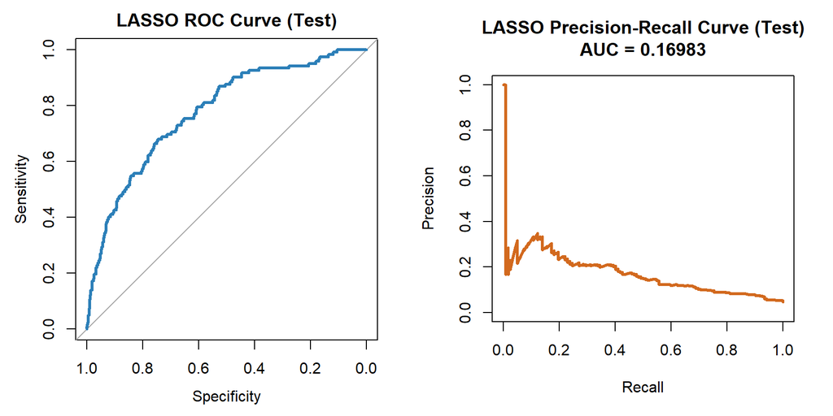

```r
# Display LASSO ROC and PR Curves on Test Data
par(mfrow = c(1, 2))
plot(roc_test_lasso, col = "#2C7FB8", lwd = 3, main = "LASSO ROC Curve (Test)")
plot(pr_test_lasso, col = "chocolate", lwd = 3, main = "LASSO Precision-Recall Curve (Test)")
```

```r
par(mfrow = c(1, 1))

# Optimal decision threshold set for clinical sensitivity target (>= 80%)
threshold_lasso <- 0.395
ypred_train_class <- ifelse(ypred_train >= threshold_lasso, 1, 0)
ypred_test_class  <- ifelse(ypred_test  >= threshold_lasso, 1, 0)

cm_train_lasso <- confusionMatrix(table(factor(ypred_train_class, levels=c(0,1)), factor(y_train_num, levels=c(0,1))), positive = "1")
cm_test_lasso  <- confusionMatrix(table(factor(ypred_test_class, levels=c(0,1)), factor(y_test_num, levels=c(0,1))), positive = "1")

# Format metrics table
lasso_metrics <- data.frame(
  Metric = c("Sensitivity", "Specificity", "PPV", "NPV", "Balanced Accuracy", "Accuracy", "AUC", "AUC-PR"),
  Training = round(c(cm_train_lasso$byClass["Sensitivity"], cm_train_lasso$byClass["Specificity"],
                     cm_train_lasso$byClass["Pos Pred Value"], cm_train_lasso$byClass["Neg Pred Value"],
                     cm_train_lasso$byClass["Balanced Accuracy"], cm_train_lasso$overall["Accuracy"],
                     as.numeric(auc(roc_train_lasso)), pr_train_lasso$auc.integral), 2),
  Test = round(c(cm_test_lasso$byClass["Sensitivity"], cm_test_lasso$byClass["Specificity"],
                 cm_test_lasso$byClass["Pos Pred Value"], cm_test_lasso$byClass["Neg Pred Value"],
                 cm_test_lasso$byClass["Balanced Accuracy"], cm_test_lasso$overall["Accuracy"],
                 as.numeric(auc(roc_test_lasso)), pr_test_lasso$auc.integral), 2)
)

lasso_metrics %>% gt() %>% tab_header(title = "LASSO (Lambda Min) Model Performance Metrics", subtitle = "Optimal Deviance Model (Threshold = 0.395)")
```

LASSO (Lambda Min) Model Performance Metrics

Optimal Deviance Model (Threshold = 0.395)

| Metric | Training | Test |
| --- | --- | --- |
| Sensitivity | 0.82 | 0.80 |
| Specificity | 0.60 | 0.59 |
| PPV | 0.09 | 0.09 |
| NPV | 0.99 | 0.98 |
| Balanced Accuracy | 0.71 | 0.70 |
| Accuracy | 0.61 | 0.60 |
| AUC | 0.79 | 0.78 |
| AUC-PR | 0.16 | 0.17 |

```r
# --- Additional Evaluation: LASSO with Lambda 1-SE (Parsimonious Model) ---
lasso_1se_final <- glmnet(x_train, y_train_num, alpha = 1, family = "binomial",
                          lambda = lambda_1se, weights = case_weights, standardize = TRUE)
ypred_train_1se <- as.numeric(predict(lasso_1se_final, newx = x_train, type = "response"))
ypred_test_1se  <- as.numeric(predict(lasso_1se_final, newx = x_test,  type = "response"))

roc_train_1se <- roc(y_train_num, ypred_train_1se, quiet = TRUE)
roc_test_1se  <- roc(y_test_num,  ypred_test_1se,  quiet = TRUE)

pr_test_1se_eval  <- pr.curve(scores.class0 = ypred_test_1se[y_test_num == 1],
                              scores.class1 = ypred_test_1se[y_test_num == 0], curve = FALSE)
pr_train_1se_eval <- pr.curve(scores.class0 = ypred_train_1se[y_train_num == 1],
                              scores.class1 = ypred_train_1se[y_train_num == 0], curve = FALSE)

ypred_train_class_1se <- ifelse(ypred_train_1se >= threshold_lasso, 1, 0)
ypred_test_class_1se  <- ifelse(ypred_test_1se  >= threshold_lasso, 1, 0)

cm_train_1se <- confusionMatrix(table(factor(ypred_train_class_1se, levels=c(0,1)), factor(y_train_num, levels=c(0,1))), positive = "1")
cm_test_1se  <- confusionMatrix(table(factor(ypred_test_class_1se,  levels=c(0,1)), factor(y_test_num,  levels=c(0,1))), positive = "1")

lasso_1se_metrics <- data.frame(
  Metric = c("Sensitivity", "Specificity", "PPV", "NPV", "Balanced Accuracy", "Accuracy", "AUC", "AUC-PR"),
  Training = round(c(cm_train_1se$byClass["Sensitivity"], cm_train_1se$byClass["Specificity"],
                     cm_train_1se$byClass["Pos Pred Value"], cm_train_1se$byClass["Neg Pred Value"],
                     cm_train_1se$byClass["Balanced Accuracy"], cm_train_1se$overall["Accuracy"],
                     as.numeric(auc(roc_train_1se)), pr_train_1se_eval$auc.integral), 2),
  Test = round(c(cm_test_1se$byClass["Sensitivity"], cm_test_1se$byClass["Specificity"],
                 cm_test_1se$byClass["Pos Pred Value"], cm_test_1se$byClass["Neg Pred Value"],
                 cm_test_1se$byClass["Balanced Accuracy"], cm_test_1se$overall["Accuracy"],
                 as.numeric(auc(roc_test_1se)), pr_test_1se_eval$auc.integral), 2)
)

lasso_1se_metrics %>% gt() %>% tab_header(title = "LASSO (Lambda 1-SE) Model Performance Metrics", subtitle = "Parsimonious Regularization Model (Threshold = 0.395)")
```

LASSO (Lambda 1-SE) Model Performance Metrics

Parsimonious Regularization Model (Threshold = 0.395)

| Metric | Training | Test |
| --- | --- | --- |
| Sensitivity | 0.83 | 0.84 |
| Specificity | 0.52 | 0.51 |
| PPV | 0.08 | 0.08 |
| NPV | 0.98 | 0.99 |
| Balanced Accuracy | 0.68 | 0.68 |
| Accuracy | 0.54 | 0.53 |
| AUC | 0.77 | 0.77 |
| AUC-PR | 0.16 | 0.18 |

### 4.4 LASSO Feature Importance: Lambda min vs. Lambda 1se (With and Without Dummy Variables)

I analysed feature importance under both: 1. **$\lambda_{\min}$**: Minimises cross-validated deviance (retains more predictors). 2. **$\lambda_{1\text{se}}$**: Most parsimonious model within 1 standard error of the minimum deviance (stricter penalty, fewer non-zero predictors).

For each $\lambda$, I examined: - **Individual level coefficients (including dummy variables)** to see specific category effects and direction of log-odds. - **Aggregated variable importance (excluding dummies)** using the $L_2$ norm ($\sqrt{\sum \beta^2}$) across grouped levels (e.g., combining all stroke subtypes or consciousness categories).

#### (a) Feature Importance at $\lambda_{\min}$

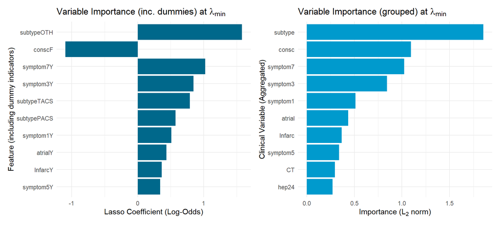

```r
# --- 1. Lambda min: Individual features (including dummy variables) ---
coef_lasso_min <- coef(lasso_cv, s = "lambda.min")
coef_df_min <- data.frame(
  variable = rownames(coef_lasso_min),
  beta = as.numeric(coef_lasso_min)
) %>%
  subset(variable != "(Intercept)" & beta != 0) %>%
  transform(
    abs_beta = abs(beta),
    odds_ratio = exp(beta)
  ) %>%
  arrange(desc(abs_beta))

p_imp_min_dum <- ggplot(head(coef_df_min, 10), aes(x = reorder(variable, abs_beta), y = beta)) +
  geom_col(fill = "deepskyblue4") +
  coord_flip() +
  labs(
    x = "Feature (including dummy indicators)",
    y = "Lasso Coefficient (Log-Odds)",
    title = expression(paste("Variable Importance (inc. dummies) at ", lambda[min]))
  ) +
  theme_minimal()

# --- 2. Lambda min: Aggregated variables without dummies (L2 norm) ---
mm <- model.matrix(death ~ ., data = data_train)
var_x <- mm[, -1, drop = FALSE]
bmat_min <- as.matrix(coef(lasso_cv, s = "lambda.min"))
beta_var_min <- bmat_min[-1, 1]

group_id <- attr(mm, "assign")[-1]
term_labels <- attr(terms(death ~ ., data = data_train), "term.labels")
group_nm <- term_labels[group_id]

beta_var_min <- beta_var_min[colnames(var_x)]
imp_lasso_min <- tapply(beta_var_min, group_nm, function(z) sqrt(sum(z^2)))

imp_df_min <- data.frame(
  variable = names(imp_lasso_min),
  importance = as.numeric(imp_lasso_min)
) %>%
  arrange(desc(importance))

p_imp_min_group <- ggplot(head(imp_df_min, 10), aes(x = reorder(variable, importance), y = importance)) +
  geom_col(fill = "deepskyblue3") +
  coord_flip() +
  labs(
    x = "Clinical Variable (Aggregated)",
    y = expression(paste("Importance (", L[2], " norm)")),
    title = expression(paste("Variable Importance (grouped) at ", lambda[min]))
  ) +
  theme_minimal()

# Display side-by-side using patchwork
p_imp_min_dum | p_imp_min_group
```

#### (b) Feature Importance at $\lambda_{1\text{se}}$ (Parsimonious Model)

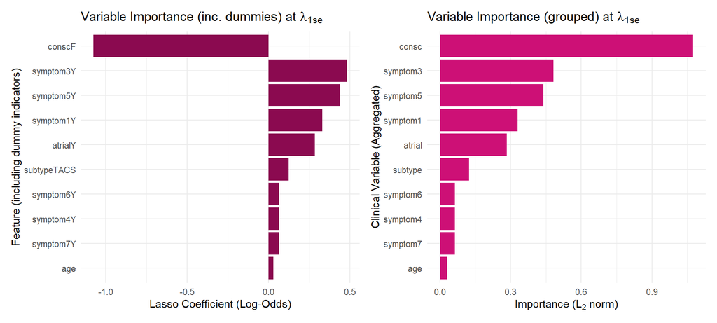

```r
# --- 3. Lambda 1se: Individual features (including dummy variables) ---
coef_lasso_1se <- coef(lasso_cv, s = "lambda.1se")
coef_df_1se <- data.frame(
  variable = rownames(coef_lasso_1se),
  beta = as.numeric(coef_lasso_1se)
) %>%
  subset(variable != "(Intercept)" & beta != 0) %>%
  transform(
    abs_beta = abs(beta),
    odds_ratio = exp(beta)
  ) %>%
  arrange(desc(abs_beta))

p_imp_1se_dum <- ggplot(head(coef_df_1se, 10), aes(x = reorder(variable, abs_beta), y = beta)) +
  geom_col(fill = "deeppink4") +
  coord_flip() +
  labs(
    x = "Feature (including dummy indicators)",
    y = "Lasso Coefficient (Log-Odds)",
    title = expression(paste("Variable Importance (inc. dummies) at ", lambda["1se"]))
  ) +
  theme_minimal()

# --- 4. Lambda 1se: Aggregated variables without dummies (L2 norm) ---
bmat_1se <- as.matrix(coef(lasso_cv, s = "lambda.1se"))
beta_var_1se <- bmat_1se[-1, 1]
beta_var_1se <- beta_var_1se[colnames(var_x)]

imp_lasso_1se <- tapply(beta_var_1se, group_nm, function(z) sqrt(sum(z^2)))

imp_df_1se <- data.frame(
  variable = names(imp_lasso_1se),
  importance = as.numeric(imp_lasso_1se)
) %>%
  arrange(desc(importance))

p_imp_1se_group <- ggplot(head(imp_df_1se, 10), aes(x = reorder(variable, importance), y = importance)) +
  geom_col(fill = "deeppink3") +
  coord_flip() +
  labs(
    x = "Clinical Variable (Aggregated)",
    y = expression(paste("Importance (", L[2], " norm)")),
    title = expression(paste("Variable Importance (grouped) at ", lambda["1se"]))
  ) +
  theme_minimal()

# Display side-by-side using patchwork
p_imp_1se_dum | p_imp_1se_group
```

```r
# Retain imp_lasso_df for downstream model comparison
imp_lasso_df <- imp_df_min
```

## 5. Tree-Based Machine Learning: XGBoost

### 5.1 Hyperparameter Grid Tuning with 5-Fold Cross-Validation

We tune `max_depth`, `min_child_weight`, `eta` (learning rate), and `colsample_bytree` using 5-fold CV to maximize **PR-AUC**.

```r
mat_train <- xgb.DMatrix(x_train, label = y_train_num)
mat_test  <- xgb.DMatrix(x_test,  label = y_test_num)

# Grid of hyperparameter combinations
tuning_grid <- expand.grid(
  max_depth = c(1, 2, 3, 4),
  min_child_weight = c(5, 10, 15, 20),
  eta = c(0.01, 0.05, 0.1),
  colsample_bytree = c(0.4, 0.6, 0.8)
)

tuning_grid$best_iter <- NA_integer_
tuning_grid$aucpr <- NA_real_

set.seed(22)
for (g in seq_len(nrow(tuning_grid))) {
  params <- list(
    objective = "binary:logistic",
    eval_metric = "aucpr",
    eta = tuning_grid$eta[g],
    subsample = 0.7,
    tree_method = "hist",
    colsample_bytree = tuning_grid$colsample_bytree[g],
    scale_pos_weight = w_pos,
    max_depth = tuning_grid$max_depth[g],
    min_child_weight = tuning_grid$min_child_weight[g]
  )

  cv_tuned <- xgb.cv(
    params = params,
    data = mat_train,
    nrounds = 1000,
    nfold = 5,
    stratified = TRUE,
    early_stopping_rounds = 40,
    maximize = TRUE,
    verbose = 0
  )

  vals <- cv_tuned$evaluation_log$test_aucpr_mean
  best_it <- which.max(vals)

  tuning_grid$best_iter[g] <- best_it
  tuning_grid$aucpr[g]     <- vals[best_it]
}

# Select optimal hyperparameter set
best_params_xgb <- tuning_grid[which.max(tuning_grid$aucpr), ]
cat("Best XGBoost Hyperparameters:\n")
```

```
## Best XGBoost Hyperparameters:
```

```r
print(best_params_xgb)
```

```
##    max_depth min_child_weight eta colsample_bytree best_iter     aucpr
## 42         2               15 0.1              0.4        72 0.1769436
```

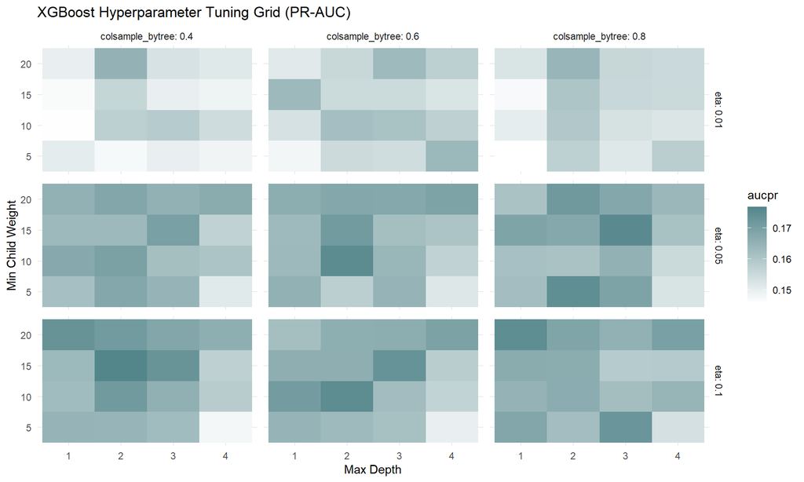

```r
# Visualise Hyperparamete heastmap
ggplot(tuning_grid, aes(x = factor(max_depth), y = factor(min_child_weight), fill = aucpr)) +
  geom_tile() +
  scale_fill_gradient(low = "white", high = "cadetblue4") +
  facet_grid(eta ~ colsample_bytree, labeller = label_both) +
  labs(title = "XGBoost Hyperparameter Tuning Grid (PR-AUC)", x = "Max Depth", y = "Min Child Weight") +
  theme_minimal()
```

### 5.2 Refitting Final XGBoost Model & Evaluation

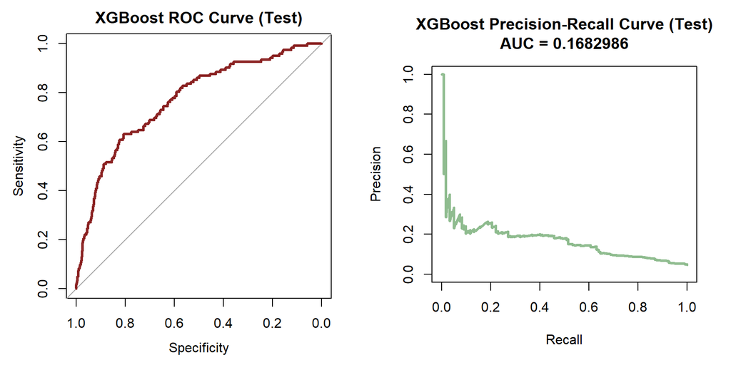

```r
final_xgb_params <- list(
  objective = "binary:logistic",
  eval_metric = "aucpr",
  tree_method = "hist",
  subsample = 0.7,
  colsample_bytree = best_params_xgb$colsample_bytree,
  min_child_weight = best_params_xgb$min_child_weight,
  max_depth = best_params_xgb$max_depth,
  eta = best_params_xgb$eta,
  scale_pos_weight = w_pos
)

set.seed(22)
xgb_final <- xgb.train(
  params = final_xgb_params,
  data = mat_train,
  nrounds = best_params_xgb$best_iter,
  verbose = 0
)

# Predict probabilities
pred_xgb_train <- predict(xgb_final, mat_train)
pred_xgb_test  <- predict(xgb_final, mat_test)

# Evaluate ROC & PR curves
roc_train_xgb <- roc(y_train_num, pred_xgb_train, quiet = TRUE)
roc_test_xgb  <- roc(y_test_num,  pred_xgb_test,  quiet = TRUE)

pr_train_xgb <- pr.curve(scores.class0 = pred_xgb_train[y_train_num == 1], scores.class1 = pred_xgb_train[y_train_num == 0], curve = TRUE)
pr_test_xgb  <- pr.curve(scores.class0 = pred_xgb_test[y_test_num == 1],   scores.class1 = pred_xgb_test[y_test_num == 0],   curve = TRUE)

# Display XGBoost ROC and PR Curves on Test Data
par(mfrow = c(1, 2))
plot(roc_test_xgb, col = "brown4", lwd = 3, main = "XGBoost ROC Curve (Test)")
plot(pr_test_xgb, col = "darkseagreen", lwd = 3, main = "XGBoost Precision-Recall Curve (Test)")
```

```r
par(mfrow = c(1, 1))

# Calibrated classification threshold
threshold_xgb <- 0.380
yhat_train_xgb <- ifelse(pred_xgb_train >= threshold_xgb, 1, 0)
yhat_test_xgb  <- ifelse(pred_xgb_test  >= threshold_xgb, 1, 0)

cm_train_xgb <- confusionMatrix(table(factor(yhat_train_xgb, levels=c(0,1)), factor(y_train_num, levels=c(0,1))), positive = "1")
cm_test_xgb  <- confusionMatrix(table(factor(yhat_test_xgb,  levels=c(0,1)), factor(y_test_num,  levels=c(0,1))), positive = "1")

xgb_metrics <- data.frame(
  Metric = c("Sensitivity", "Specificity", "PPV", "NPV", "Balanced Accuracy", "Accuracy", "AUC", "AUC-PR"),
  Training = round(c(cm_train_xgb$byClass["Sensitivity"], cm_train_xgb$byClass["Specificity"],
                     cm_train_xgb$byClass["Pos Pred Value"], cm_train_xgb$byClass["Neg Pred Value"],
                     cm_train_xgb$byClass["Balanced Accuracy"], cm_train_xgb$overall["Accuracy"],
                     as.numeric(auc(roc_train_xgb)), pr_train_xgb$auc.integral), 2),
  Test = round(c(cm_test_xgb$byClass["Sensitivity"], cm_test_xgb$byClass["Specificity"],
                 cm_test_xgb$byClass["Pos Pred Value"], cm_test_xgb$byClass["Neg Pred Value"],
                 cm_test_xgb$byClass["Balanced Accuracy"], cm_test_xgb$overall["Accuracy"],
                 as.numeric(auc(roc_test_xgb)), pr_test_xgb$auc.integral), 2)
)

xgb_metrics %>% gt() %>% tab_header(title = "XGBoost Model Performance Metrics", subtitle = paste0("Decision Threshold = ", threshold_xgb))
```

XGBoost Model Performance Metrics

Decision Threshold = 0.38

| Metric | Training | Test |
| --- | --- | --- |
| Sensitivity | 0.84 | 0.83 |
| Specificity | 0.56 | 0.55 |
| PPV | 0.09 | 0.08 |
| NPV | 0.99 | 0.98 |
| Balanced Accuracy | 0.70 | 0.69 |
| Accuracy | 0.58 | 0.56 |
| AUC | 0.80 | 0.77 |
| AUC-PR | 0.19 | 0.17 |

```r
# --- XGBoost Confusion Matrix Table: Train vs. Test ---
cm_xgb_combined <- data.frame(
  Prediction = c("Predicted Survived (0)", "Predicted Survived (0)", "Predicted Died (1)", "Predicted Died (1)"),
  Observed   = c("Actual Survived (0)", "Actual Died (1)", "Actual Survived (0)", "Actual Died (1)"),
  Classification = c("True Negative (TN)", "False Negative (FN)", "False Positive (FP)", "True Positive (TP)"),
  Training_Count = c(
    cm_train_xgb$table[1, 1], # Pred 0, Obs 0
    cm_train_xgb$table[1, 2], # Pred 0, Obs 1
    cm_train_xgb$table[2, 1], # Pred 1, Obs 0
    cm_train_xgb$table[2, 2]  # Pred 1, Obs 1
  ),
  Test_Count = c(
    cm_test_xgb$table[1, 1],
    cm_test_xgb$table[1, 2],
    cm_test_xgb$table[2, 1],
    cm_test_xgb$table[2, 2]
  )
)

cm_xgb_gt <- cm_xgb_combined %>%
  gt() %>%
  tab_header(
    title = "XGBoost Confusion Matrix Counts",
    subtitle = paste0("Training vs. Test Set Comparison (Threshold = ", threshold_xgb, ")")
  ) %>%
  cols_label(
    Prediction = "Model Prediction",
    Observed = "Actual Outcome",
    Classification = "Classification Type",
    Training_Count = "Training Set (N)",
    Test_Count = "Test Set (N)"
  ) %>%
  tab_style(
    style = cell_text(weight = "bold"),
    locations = cells_column_labels(everything())
  )

cm_xgb_gt
```

XGBoost Confusion Matrix Counts

Training vs. Test Set Comparison (Threshold = 0.38)

| Model Prediction | Actual Outcome | Classification Type | Training Set (N) | Test Set (N) |
| --- | --- | --- | --- | --- |
| Predicted Survived (0) | Actual Survived (0) | True Negative (TN) | 5603 | 1374 |
| Predicted Survived (0) | Actual Died (1) | False Negative (FN) | 76 | 21 |
| Predicted Died (1) | Actual Survived (0) | False Positive (FP) | 4358 | 1116 |
| Predicted Died (1) | Actual Died (1) | True Positive (TP) | 414 | 101 |

### 5.3 SHAP (SHapley Additive exPlanations) Model Interpretability

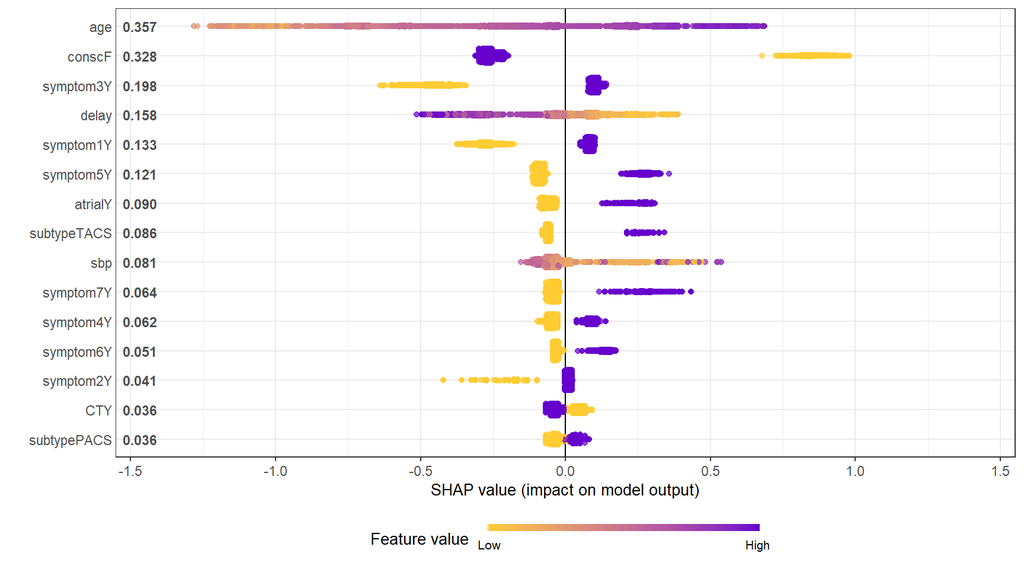

```r
# Calculate SHAP values on validation set
shap_plot <- shap.plot.summary.wrap1(xgb_final, X = as.matrix(x_test), top_n = 15)
shap_plot
```

## 6. Model Comparison & Synthesis

### 6.1 Log Loss (Binary Cross-Entropy) Benchmarking

$$\text{Log Loss} = -\frac{1}{N}
\sum_{i=1}^N \left[ y_i \log(p_i) + (1-y_i) \log(1-p_i)
\right]$$

```r
calc_logloss <- function(y, p, eps = 1e-15) {
  p <- pmin(pmax(p, eps), 1 - eps)
  -mean(y * log(p) + (1 - y) * log(1 - p))
}

logloss_summary <- data.frame(
  Model = c("LASSO Regularized Regression", "XGBoost Gradient Boosting"),
  Train_LogLoss = round(c(calc_logloss(y_train_num, ypred_train), calc_logloss(y_train_num, pred_xgb_train)), 4),
  Test_LogLoss  = round(c(calc_logloss(y_test_num,  ypred_test),  calc_logloss(y_test_num,  pred_xgb_test)), 4)
)

logloss_summary %>% gt(rowname_col = "Model") %>% tab_header(title = "Log Loss Comparison")
```

Log Loss Comparison

|  | Train_LogLoss | Test_LogLoss |
| --- | --- | --- |
| LASSO Regularized Regression | 0.5611 | 0.5667 |
| XGBoost Gradient Boosting | 0.5458 | 0.5571 |

### 6.2 Feature Importance Comparison Across Models

I normalise importance metrics ($[0, 1]$ scale) to directly compare LASSO coefficient magnitudes against XGBoost Gain.

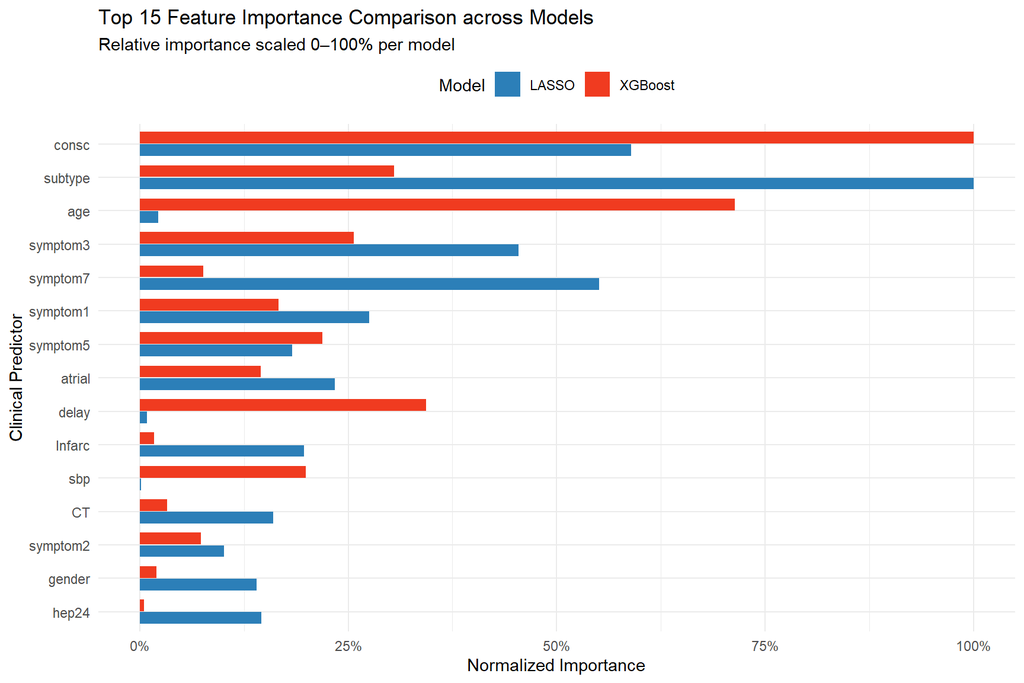

```r
# Aggregate XGBoost Gain back to original variable groups
col_to_var <- data.frame(
  Feature = colnames(mm[, -1, drop = FALSE]),
  variable = term_labels[group_id],
  stringsAsFactors = FALSE
)

var_imp_xgb <- xgb.importance(feature_names = colnames(x_train), model = xgb_final)
vars_xgb <- var_imp_xgb %>%
  left_join(col_to_var, by = "Feature") %>%
  group_by(variable) %>%
  summarise(Gain = sum(Gain), .groups = "drop")

# Merge importance scores
comp_imp <- merge(imp_lasso_df, vars_xgb, by = "variable", all = TRUE) %>%
  mutate(
    importance = replace_na(importance, 0),
    Gain       = replace_na(Gain, 0),
    lasso_norm = if (max(importance) > 0) importance / max(importance) else 0,
    xgb_norm   = if (max(Gain) > 0) Gain / max(Gain) else 0,
    combined_score = (lasso_norm + xgb_norm) / 2
  ) %>%
  slice_max(combined_score, n = 15) %>%
  arrange(combined_score) %>%
  mutate(variable = factor(variable, levels = variable)) %>%
  select(variable, LASSO = lasso_norm, XGBoost = xgb_norm) %>%
  pivot_longer(-variable, names_to = "Model", values_to = "Normalized_Importance")

ggplot(comp_imp, aes(x = variable, y = Normalized_Importance, fill = Model)) +
  geom_col(position = position_dodge(width = 0.75), width = 0.7) +
  coord_flip() +
  scale_y_continuous(labels = percent_format(accuracy = 1)) +
  scale_fill_manual(values = c("LASSO" = "#2C7FB8", "XGBoost" = "#F03B20")) +
  labs(
    title = "Top 15 Feature Importance Comparison across Models",
    subtitle = "Relative importance scaled 0–100% per model",
    x = "Clinical Predictor",
    y = "Normalized Importance"
  ) +
  theme_minimal() +
  theme(legend.position = "top")
```